# General(ized) Linear Models: Other Distributions

## Hierarchy of GLMs

[figure not shown]

## *Generalized* linear models

\[\mbox{Response variable(s)} \sim \mbox{Predictor variable(s)} + \mbox{Error}\]

Distribution of the response variable(s) can be:

1. Normal (Gaussian)
2. Binomial (two states)
3. Poisson (counts)
4. Lots and lots of others

## General equation form of GLMs

\[Y = \beta_0 + \beta_1X_1 + \beta_2X_2 + \dots + \beta_nX_n\]

\(Y\) follows some distribution (e.g., \(Y \sim \mathcal{N}\) or \(Y \sim \mbox{Binom}\))

- Most often normal.

\(X_n\) are some combination of continuous and categorical predictors.

\(\beta_n\) are the parameter estimates for the \(X\).

## Logistic regression

Outcome variable is categorical:

- Heart disease
- Diabetes
- Cancer

Predictors can be a mix of categorical and continuous variables:

- sex, smoking status, family history of …
- body mass, BMI, blood glucose level

## Logistic regression

What are the predictors of presence or absence?

- Morphology
- Character state
- Species
- Rain

## Link functions

1. Gaussian: Identity
2. Binomial: Logit
3. Poisson: Log

## Logistic regression

\[\mbox{logit}(Y) = \beta_0 + \beta_1X_1 + \beta_2X_2 + \dots + \beta_nX_n\]

The logit “transformation” allows \(\beta\)s to be estimated iteratively.

Fitting in R:

- `glm()` uses the formula interface
- `family =` determines the link function
  - “Gaussian” \(\rightarrow\) identity
  - “binomial” \(\rightarrow\) logit
  - “Poisson” \(\rightarrow\) log

## Logistic regression

```r
set.seed(4)
rainfall <- c(runif(20, 100, 160),
              runif(20, 160, 210))
presence <- c(rbinom(20, 1, 0.15),
              rbinom(20, 1, 0.95))
LogReg <- data.frame(Rainfall = rainfall,
                     Presence = as.factor(presence))
head(LogReg)
```

```
##   Rainfall Presence
## 1 135.1480        1
## 2 100.5367        0
## 3 117.6244        0
## 4 116.6425        0
## 5 148.8145        1
## 6 115.6257        0
```

## Fitting a logistic model

```r
fm <- glm(Presence ~ Rainfall,
          data = LogReg,
          family = "binomial")
```

*Note*: `Presence` is a factor with two levels

## Summarizing

```r
summary(fm)
```

```
##
## Call:
## glm(formula = Presence ~ Rainfall, family = "binomial", data = LogReg)
##
## Deviance Residuals:
##     Min       1Q   Median       3Q      Max
## -2.1916  -0.5460   0.3079   0.4700   2.2717
##
## Coefficients:
##             Estimate Std. Error z value Pr(>|z|)
## (Intercept) -8.83416    2.75346  -3.208 0.001335 **
## Rainfall     0.05974    0.01772   3.372 0.000747 ***
## ---
## Signif. codes:  0 '***' 0.001 '**' 0.01 '*' 0.05 '.' 0.1 ' ' 1
##
## (Dispersion parameter for binomial family taken to be 1)
##
##     Null deviance: 52.925  on 39  degrees of freedom
## Residual deviance: 32.729  on 38  degrees of freedom
## AIC: 36.729
##
## Number of Fisher Scoring iterations: 5
```

## Summarizing with `logistic.display()`

```r
library(epiDisplay)
logistic.display(fm)
```

```
##
## Logistic regression predicting Presence : 1 vs 0
##
##                       OR(95%CI)        P(Wald's test) P(LR-test)
## Rainfall (cont. var.) 1.06 (1.03,1.1)  < 0.001        < 0.001
##
## Log-likelihood = -16.3643
## No. of observations = 40
## AIC value = 36.7285
```

## Visualizing

```r
ggplot(LogReg, aes(x = Rainfall,
                   y = as.numeric(Presence) - 1)) +
  geom_hline(yintercept = 0.5, linetype = "dotted", size = 0.5) +
  geom_smooth(formula = y ~ x,
              method = "glm",
              method.args = list(family = "binomial"),
              se = FALSE, size = 2) +
  geom_point(size = 3) +
  ylab("Probability of Presence") +
  xlab("Rainfall (cm/y)") +
  scale_y_continuous(breaks = seq(0, 1, by = 0.1))
```

## Visualizing

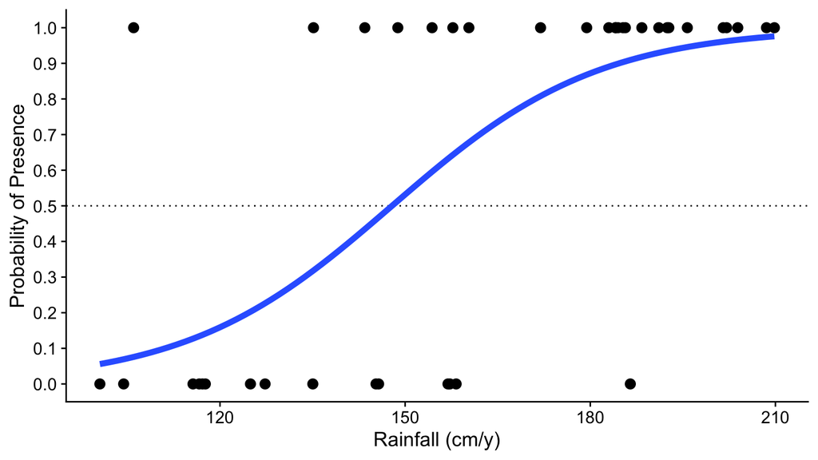

## Presence of sole

[figure not shown]

## Presence of sole

Presence/absence of sole in the Tagus estuary of Portugal.

```r
M <- read_excel("../data/Sole.xlsx")
str(M)
```

```
## tibble [65 × 13] (S3: tbl_df/tbl/data.frame)
##  $ Sample       : num [1:65] 1 2 3 4 5 6 7 8 9 10 ...
##  $ season       : num [1:65] 1 1 1 1 1 1 1 1 1 1 ...
##  $ month        : num [1:65] 5 5 5 5 5 5 5 5 5 5 ...
##  $ area         : num [1:65] 2 2 2 4 4 4 3 3 3 1 ...
##  $ depth        : num [1:65] 3 2.6 2.6 2.1 3.2 3.5 1.6 1.7 1.8 4.5 ...
##  $ temperature  : num [1:65] 20 18 19 20 20 20 19 17 19 21 ...
##  $ salinity     : num [1:65] 30 29 30 29 30 32 29 28 29 12 ...
##  $ transparency : num [1:65] 15 15 15 15 15 7 15 10 10 35 ...
##  $ gravel       : num [1:65] 3.74 1.94 2.88 11.06 9.87 ...
##  $ large_sand   : num [1:65] 13.15 4.99 8.98 11.96 28.6 ...
##  $ med_fine_sand: num [1:65] 11.93 5.43 16.85 21.95 19.49 ...
##  $ mud          : num [1:65] 71.2 87.6 71.3 55 42 ...
##  $ Solea_solea  : num [1:65] 0 0 1 0 0 0 1 1 0 1 ...
```

## Presence of sole

```r
M$Solea_solea <- factor(M$Solea_solea)
fm <- glm(Solea_solea ~ salinity, data = M, family = "binomial")
```

## Presence of sole

```
##
## Call:
## glm(formula = Solea_solea ~ salinity, family = "binomial", data = M)
##
## Deviance Residuals:
##     Min       1Q   Median       3Q      Max
## -2.0674  -0.7146  -0.6362   0.7573   1.8997
##
## Coefficients:
##             Estimate Std. Error z value Pr(>|z|)
## (Intercept)  2.66071    0.90167   2.951 0.003169 **
## salinity    -0.12985    0.03494  -3.716 0.000202 ***
## ---
## Signif. codes:  0 '***' 0.001 '**' 0.01 '*' 0.05 '.' 0.1 ' ' 1
##
## (Dispersion parameter for binomial family taken to be 1)
##
##     Null deviance: 87.492  on 64  degrees of freedom
## Residual deviance: 68.560  on 63  degrees of freedom
## AIC: 72.56
##
## Number of Fisher Scoring iterations: 4
```

## Presence of sole

```r
logistic.display(fm)
```

```
##
## Logistic regression predicting Solea_solea : 1 vs 0
##
##                       OR(95%CI)         P(Wald's test) P(LR-test)
## salinity (cont. var.) 0.88 (0.82,0.94)  < 0.001        < 0.001
##
## Log-likelihood = -34.28
## No. of observations = 65
## AIC value = 72.56
```

## Presence of sole

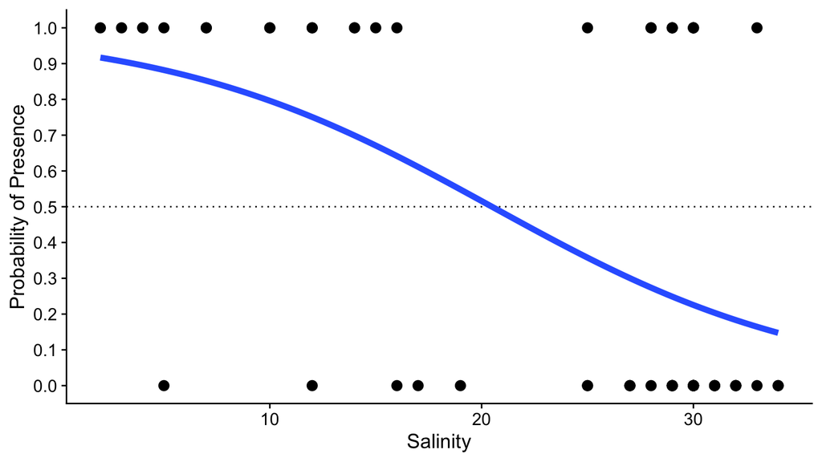

## Number of sole

```r
M2 <- M %>% group_by(season, month, area) %>%
              summarize(number_sole = sum(as.numeric(Solea_solea)),
                        avg_salinity = mean(salinity),
                        .groups = "drop")
```

## Number of sole

```r
fm2 <- glm(number_sole ~ avg_salinity, data = M2, family = "poisson")
```

## Number of sole

```r
summary(fm2)
```

```
##
## Call:
## glm(formula = number_sole ~ avg_salinity, family = "poisson",
##     data = M2)
##
## Deviance Residuals:
##      Min        1Q    Median        3Q       Max
## -0.61650  -0.29124   0.04783   0.25881   0.55893
##
## Coefficients:
##              Estimate Std. Error z value Pr(>|z|)
## (Intercept)   2.27852    0.26281   8.670  < 2e-16 ***
## avg_salinity -0.03244    0.01090  -2.977  0.00291 **
## ---
## Signif. codes:  0 '***' 0.001 '**' 0.01 '*' 0.05 '.' 0.1 ' ' 1
##
## (Dispersion parameter for poisson family taken to be 1)
##
##     Null deviance: 10.7401  on 19  degrees of freedom
## Residual deviance:  2.3786  on 18  degrees of freedom
## AIC: 73.123
##
## Number of Fisher Scoring iterations: 4
```

## Number of sole

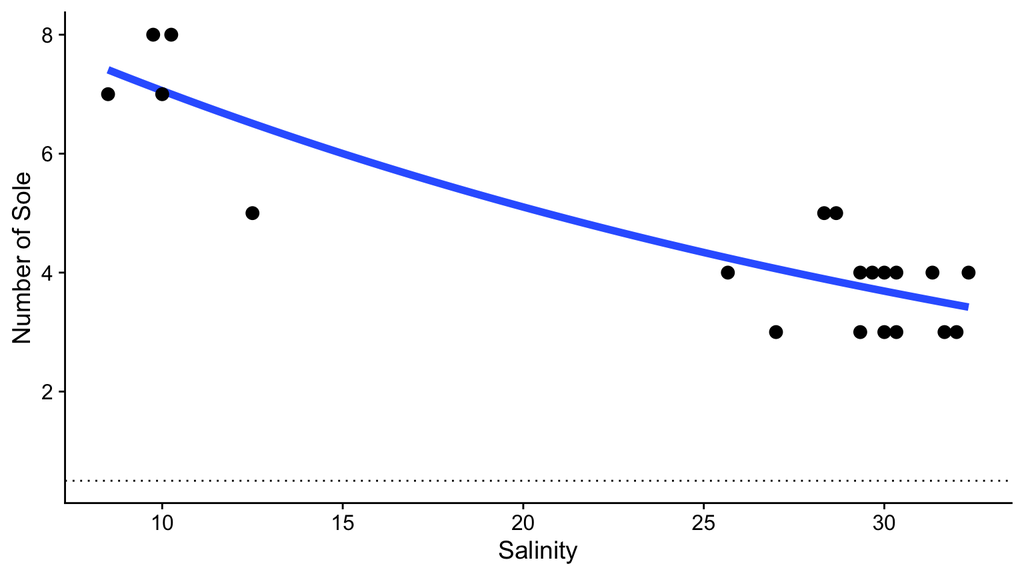

## Tibetan skulls

Morant (1923) published data on 32 skulls from Tibet

[figure not shown]

## Tibetan skulls

```r
M <- read_excel("../data/Tibetan_Skulls.xlsx")
str(M)
```

```
## tibble [32 × 6] (S3: tbl_df/tbl/data.frame)
##  $ Skull_Length: num [1:32] 190 172 167 170 175 ...
##  $ Skull_Width : num [1:32] 152 132 130 150 138 ...
##  $ Skull_Height: num [1:32] 145 126 126 134 126 ...
##  $ Face_Height : num [1:32] 73.5 63 69.5 64.5 77.5 71.5 70.5 73.5 70 62 ...
##  $ Face_Breadth: num [1:32] 136 121 120 128 136 ...
##  $ Origin      : chr [1:32] "Sikkim" "Sikkim" "Sikkim" "Sikkim" ...
```

```r
M <- M %>% mutate(Origin = factor(Origin))
```

## Tibetan skulls

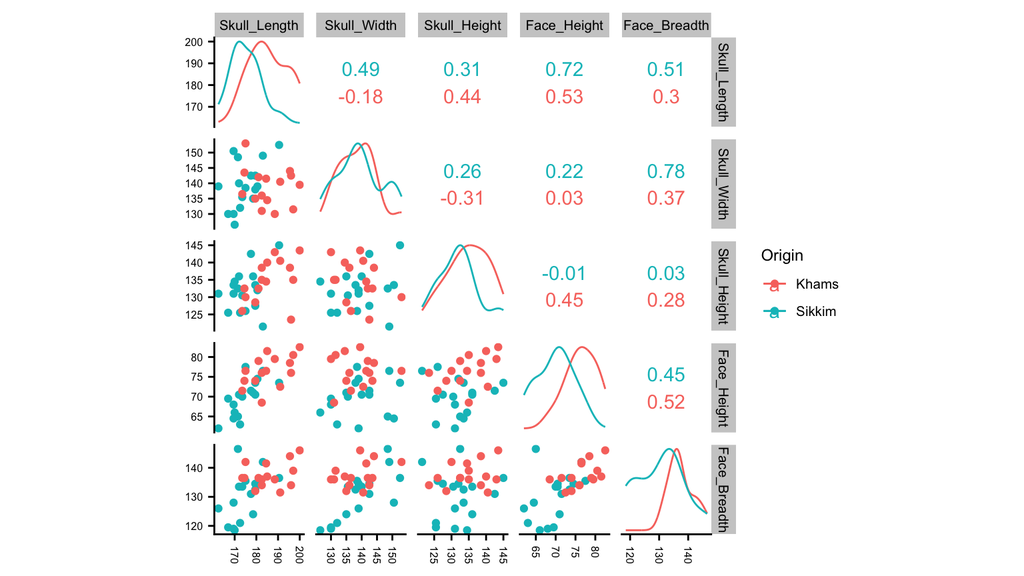

## Tibetan skulls

```r
fm <- glm(Origin ~ ., data = M, family = "binomial")
```

- Use `~ .` to include all other variables

## Tibetan skulls

```
##
## Call:
## glm(formula = Origin ~ ., family = "binomial", data = M)
##
## Deviance Residuals:
##      Min        1Q    Median        3Q       Max
## -1.61850  -0.36347   0.00947   0.44172   1.55552
##
## Coefficients:
##              Estimate Std. Error z value Pr(>|z|)
## (Intercept)  73.51908   44.81155   1.641   0.1009
## Skull_Length -0.12895    0.09688  -1.331   0.1832
## Skull_Width   0.32337    0.18138   1.783   0.0746 .
## Skull_Height -0.10429    0.12311  -0.847   0.3969
## Face_Height  -0.33545    0.23132  -1.450   0.1470
## Face_Breadth -0.42403    0.27276  -1.555   0.1200
## ---
## Signif. codes:  0 '***' 0.001 '**' 0.01 '*' 0.05 '.' 0.1 ' ' 1
##
## (Dispersion parameter for binomial family taken to be 1)
##
##     Null deviance: 44.236  on 31  degrees of freedom
## Residual deviance: 20.162  on 26  degrees of freedom
## AIC: 32.162
##
## Number of Fisher Scoring iterations: 7
```

## Tibetan skulls

```r
logistic.display(fm)
```

```
##
## Logistic regression predicting Origin : Sikkim vs Khams
##
##                           crude OR(95%CI)   adj. OR(95%CI)    P(Wald's test)
## Skull_Length (cont. var.) 0.83 (0.72,0.95)  0.88 (0.73,1.06)  0.183
##
## Skull_Width (cont. var.)  1.01 (0.91,1.12)  1.38 (0.97,1.97)  0.075
##
## Skull_Height (cont. var.) 0.92 (0.82,1.04)  0.9 (0.71,1.15)   0.397
##
## Face_Height (cont. var.)  0.68 (0.53,0.89)  0.72 (0.45,1.13)  0.147
##
## Face_Breadth (cont. var.) 0.83 (0.71,0.97)  0.65 (0.38,1.12)  0.12
##
##                           P(LR-test)
## Skull_Length (cont. var.) 0.151
##
## Skull_Width (cont. var.)  0.014
##
## Skull_Height (cont. var.) 0.375
##
## Face_Height (cont. var.)  0.088
##
## Face_Breadth (cont. var.) 0.026
##
## Log-likelihood = -10.081
## No. of observations = 32
## AIC value = 32.162
```

## Tibetan skulls

```r
Anova(fm, type = "III")
```

```
## Analysis of Deviance Table (Type III tests)
##
## Response: Origin
##              LR Chisq Df Pr(>Chisq)
## Skull_Length   2.0626  1    0.15095
## Skull_Width    5.9786  1    0.01448 *
## Skull_Height   0.7866  1    0.37512
## Face_Height    2.9075  1    0.08817 .
## Face_Breadth   4.9508  1    0.02608 *
## ---
## Signif. codes:  0 '***' 0.001 '**' 0.01 '*' 0.05 '.' 0.1 ' ' 1
```

## Generalized linear multilevel models

Generalization of Gaussian multilevel models to all the kinds of predictors that generalized linear models can be used for

Large can of worms:

- http://glmm.wikidot.com/faq

Morant, G. M. 1923. A First Study of the Tibetan Skull. *Biometrika* 14:193–260.